# Open Refine Demo

Mark Dunning

Last modified: 04 Jan 2021

[figure not shown]

(for more detail see [Data Carpentry materials](http://www.datacarpentry.org/OpenRefine-ecology-lesson/))

Open Refine (previously Google Refine) is an open-source tool that can help you to clean-up messy datasets. It presents itself as a spreadsheet-like interface, but all operations we do to the data are recorded and can be repeated or reversed. We will show how it can be used to solve some of the issues we have highlighted previously. You can use Open Refine to build-up a data-cleaning pipeline which you can apply to multiple files. We will not go that far today though. There are some nice introductory videos

[video not shown]

Open Refine runs in a web browser, although you do not have to be online to use it.

## Downloading and installation

OpenRefine 3.4.1 can be [downloaded](http://openrefine.org/download.html) and installed for various operating systems

## Some example data

We will use some data that have been simulated to demonstrate many of the problems we have seen already. Each row represents a different patient in a fictitious study and can be downloaded from the course website. (Right-click and `Save Link as....`)

## Importing the data

Start the program. On Windows, Double-click on the openrefine.exe file. Java services will start on your machine, and Refine will open in your Firefox browser. On the Mac, you’ve probably installed the package into your Applications folder.

Note the file types Open Refine handles: TSV, CSV, *SV, Excel (.xls .xlsx), JSON, XML, RDF as XML, Google Data documents. Support for other formats can be added with Google Refine extensions.

Once Refine is open, you’ll be asked if you want to Create, Open, or Import a Project.

[figure not shown]

If all looks well, click *Create Project*.

## Faceting

*Faceting* provides you a snapshot of the entries in a particular column and allows you to filter down to particular rows. It can also quickly highlight problems with the data.

Typically, you create a facet on a particular column. The facet summarizes the cells in that column to give you a big picture on that column, and allows you to filter to some subset of rows for which their cells in that column satisfy some constraint. That’s a bit abstract, so let’s jump into some examples. Before we start, *how many different entries would we expect to find a column that is supposed to denote whether somebody smokes or not`?*

- Scroll over to the `Smokes` column
- Click the down arrow and choose *Facet* -> *Text facet*
- In the left margin, you’ll see a box containing every unique, distinct value in the `Smokes` column and Refine shows you how many times that value occurs in the column (a count), and allows you to sort (order) your facets by name or count.

In this case, we have found many different ways for the smoking status to be recorded.

Edit. Note that at any time, in any cell of the Facet box, or data cell in the Refine window, you have access to edit and can fix an error immediately. Refine will even ask you if you’d like to make that same correction to every value it finds like that one (or not).

## Trimming whitespace

*Whitespace* is when we have a blank space at the beginning, or end, of a text entry. They can be difficult to spot by-eye and for the computer `Yes` and `Yes` are completely distinct entries. This can have undesired consequences in a data analysis.

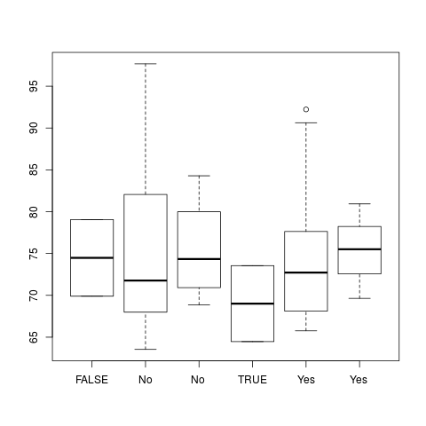

Fortunately, Open Refine has a straightforward solution to this problem

- Select the `Smokes` column
- Select *Edit cells*
- *Common transforms* -> *Trim trailing and leading whitespace*

## Clustering

- Click on `No` in the Facet panel. Only rows where the value of `Smokes` is `No` will be shown.
- Click on the *edit* box `No` value in any particular row. This will give you the chance to edit the value.
- Change the value to `FALSE`. Clicking *Apply to all identical cells* will change all occurrences of `No` to `FALSE`.
- You could also try changing `Yes` to `TRUE`…

## Splitting into several columns

Sometimes multiple pieces of information can be encoded in a single cell. In our particular case, the ID assigned to each patient contains a hospital identifier (either `AH` or `SG`) and a numeric ID. For some analyses we might want to quickly perform operations that take the hospital as a factor

## Filling missing values

The final column `Date entered study` was used to indicate the date at which each patient was enrolled onto the study in question. Patients were enrolled in batches. However, the person filling out the form thought it was helpful to include this information only once for each batch of new patients.

- Select the `Date Entered Study` column
- Select *Edit cells* -> *Fill down*
- Empty cells will now be filled with the appropriate date.

## Upper- and lower-case transformations

For consistency, we might want the text entries in a particular column to be all `lower` or `UPPPER` case.

- Select the `Name` column
- *Edit column* -> *Common transformations*
- You can choose `To uppercase`, `To lowercase` if required.
- However, we will use the operation `To titlecase`. It makes the first letter of the text *Upper case*, but the rest of the text *Lower case*.

## More-advanced text operations

Open Refine has it’s own language (“General Refine Expression language (GREL)”) for performing custom text operations in a column.

- Select the `Height` column
- Select *Edit cells* -> *Transform…*
- In the Expression box, enter `replace(value, "cm","")`

We can now explicitly convert the Height values into numbers

- Select *Edit cells* -> *Common Transformations* -> *To number*

It is now possible to facet the column by number rather than text. This allows potential outlier values to be identified

- *Facet* -> *Numeric Facet*

# Questions

- Split the `Birth` column into Year, Month and Day
- Tidy up the following columns ready for analysis:-
  - `Weight`
  - `Grade_Level`
  - `Count`
- Look at the `State` column and try faceting / clustering. Are there any entries that should be joined into one? You may need to experiment with different clustering methods.

## Exporting your data / project

You can export the modified table into a new file:-

- *Export* -> *Tab-separated value* or *Export* -> *Comma-separated value* would seem to be sensible choices.

# Impact on analysis

## After cleaning

```
patients <- read.delim("patient-data-cleaned.tsv")
boxplot(patients$Weight ~patients$Smokes)
```

[figure not shown]

## Before cleaning

[output not shown]